# Tutorial series: using pyPAHdb to analyze astronomical spectra.

# Tutorial 01: a single Spitzer spectrum.

We begin this series by performing a simple analysis of a single astronomical spectrum. We will use one of the sample spectra here. Feel free to follow along, and attempt the same method with a simple spectrum of your own.

Data used in this example: pyPAHdb/tests/data/NGC7023-NW-PAHs.txt

## Step 1: Necessary modules and paths

```python
# The below command will suppress the shell output, since we are using
# matplotlib within a notebook.
%matplotlib inline

import matplotlib.pyplot as plt
import numpy as np
import os
import pkg_resources
import pypahdb
```

## Step 2: Preparing the data

You should ensure your data has a simple format. Acceptable formats include:

- FITS
  - ...
- ASCII
  - either two-column (wavelength, flux) or three-column (wavelength, flux, flux error)
  - seperated by commas (CSV) or single spaces
  - *what about headers?? do we use skiprows in pypahdb right now??*

### Load the data

We will use the example spectrum `NGC7023-NW-PAHs.txt` here.

```python
# Loading from the data directory. For your uses, point to the location
# of the spectrum you are examining.
# data_file = data_dir + 'NGC7023-NW-PAHs.txt'
data_file = pkg_resources.resource_filename('pypahdb', 'tests/data/NGC7023-NW-PAHs.txt')
data_file
```

```
'/Users/koma/Documents/GitHub/pyPAHdb/pypahdb/tests/data/NGC7023-NW-PAHs.txt'
```

Let's examine the first few lines of this file so we understand its structure...

```python
for index, line in enumerate(open(data_file, 'r')):
    print(line, end='')
    if index >= 3:
        break
```

```
wavelength "surface brightness"
5.24282 50.918551188790325
5.2738 53.081826767577795
5.30479 55.46148169840347
```

So we have two columns separated by a space, the first being wavelength and the second being surface brightness (for convenience we'll call this flux). The line breaks (\n) will be handled easily by np.loadtxt (or any other module you desire):

```python
wave, flux = np.loadtxt(data_file, delimiter=' ', dtype='float', skiprows=1).T
```

We used .T to transpose the array (such that it's column-oriented).

Now let's check its dimensions and type(s).

```python
len(wave), len(flux), type(wave), type(wave[0]), type(flux[0])
```

```
(194, 194, numpy.ndarray, numpy.float64, numpy.float64)
```

### Examine the data

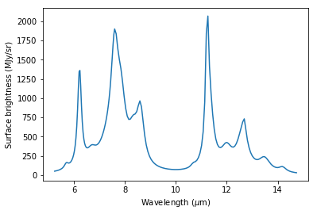

```python
plt.plot(wave, flux);
plt.xlabel(r'Wavelength ($\mu$m)');
plt.ylabel('Surface brightness (MJy/sr)');
```

We see that it is a reasonably smooth spectrum composed of Spitzer/IRS observations using the SL module (SL1 and SL2, covering ~5-14 microns approximately).

The data needs to be monotonic, i.e. not double-valued or out of order (as determined by the wavelength array).

```python
def strictly_increasing(L):
    return all(x<y for x, y in zip(L, L[1:]))

strictly_increasing(wave)
```

```
True
```

## Step 3: Running pyPAHdb (short version)

### 1. Instantiate an `observation` object

All that's needed is the path to the text file above. **can it accept both space and CSV files ????**

```python
observation = pypahdb.observation(data_file)
```

```python
observation.file_path
```

```
'/Users/koma/Documents/GitHub/pyPAHdb/pypahdb/tests/data/NGC7023-NW-PAHs.txt'
```

Now we have an `observation` object that encapsulates our data.

### 2. Pass the spectrum to `decomposer`

Now with our `observation` instance, we simply pass its spectrum to the pyPAHdb `decomposer`, which will perform the decomposition by PAH.

```python
result = pypahdb.decomposer(observation.spectrum)
```

Now we have a `decomposer` object that encapsulates the fit.

### 3. Plot and save the results using `writer`

`pypahdb.writer` is a convenient way to view and save your results.

```python
# write results to file
# by default, will save PDF and FITS files; can turn off with save_pdf=False as an argument.
# by default, saves output to the directory containing the input file;
# can instead save to a user-defined directory by setting output_directory.
# e.g., output_directory='' will save to the local folder.
pypahdb.writer(result);
```

```
Saved:  /Users/koma/Documents/GitHub/pyPAHdb/pypahdb/tests/data/NGC7023-NW-PAHs_pypahdb.pdf
Saved:  /Users/koma/Documents/GitHub/pyPAHdb/pypahdb/tests/data/NGC7023-NW-PAHs_pypahdb.fits
```

## Step 3: Running pyPAHdb (long version with details)

### 1. Instantiate an `observation` object

All that's needed is the path to the text file above. **can it accept both space and CSV files ????**

```python
observation = pypahdb.observation(data_file)
```

Now we have an `observation` object that encapsulates our data.

```python
observation.file_path
```

[output not shown]

The wavelength array is contained within `observation.spectrum.abscissa`.

```python
type(observation.spectrum.abscissa)
```

```
numpy.ndarray
```

```python
observation.spectrum.abscissa[:10]
```

```
array([5.24282, 5.2738 , 5.30479, 5.33577, 5.36676, 5.39774, 5.42873,
       5.45971, 5.4907 , 5.52169])
```

```python
observation.spectrum.abscissa.shape
```

```
(194,)
```

The flux array is within `observation.spectrum.ordinate`.

```python
type(observation.spectrum.ordinate)
```

```
numpy.ndarray
```

```python
observation.spectrum.ordinate.shape
```

```
(194, 1, 1)
```

### 2. Pass the spectrum to `decomposer`

Now with our `observation` instance, we simply pass its spectrum to the pyPAHdb `decomposer`, which will perform the decomposition by PAH.

**seems like you shouldn't need to specify observation.spectrum?? just observation? or...?**

```python
result = pypahdb.decomposer(observation.spectrum)
```

```python
type(result)
```

```
pypahdb.decomposer.decomposer
```

```python
type(result.charge)
```

```
dict
```

```python
type(result.fit)
```

```
numpy.ndarray
```

```python
type(result.ionized_fraction)
```

```
numpy.ndarray
```

```python
type(result.large_fraction)
```

```
numpy.ndarray
```

```python
type(result.norm)
```

```
numpy.ndarray
```

```python
type(result.size)
```

```
dict
```

```python
type(result.spectrum)
```

```
pypahdb.spectrum.spectrum
```